# Tips on Displaying Survey Data: Tables, Graphs, and Data Suppression

Lecture 10D

PUBHBIO 6250

## Tables with Survey Data

- Tabular displays of estimates from survey data are very common
  - Goal often is to **describe characteristics of a population**
- In a table of such summaries, we usually show:
  - Sample size (in domain), $n$
  - Weighted estimate of population size (in domain), $N$ (i.e., sum of weights)
  - Weighted estimate of mean/proportion
  - Appropriate summary of variability accounting for survey design
    - Standard errors (from linearization or replicate weights)
    - Confidence intervals
- Even though we use the weights to produce estimates for the population, showing the actual sample size is also important

## Example: Published Analysis Using OMAS 2015

*Healthcare Disparities between Children with Developmental Disabilities and Typically Developing Children in Ohio* – [Child Indicators Research](https://doi.org/10.1007/s12187-018-9546-3)

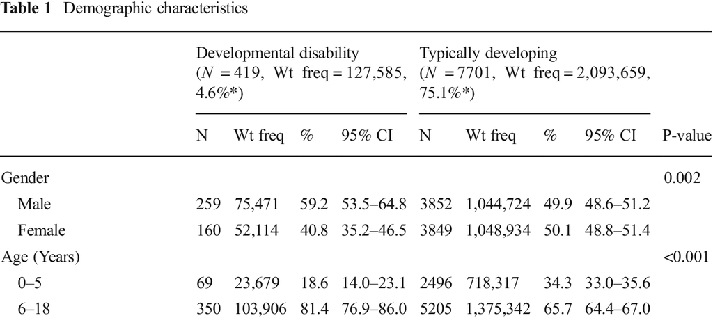

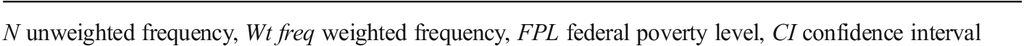

## Graphs with Survey Data

- **Always show weighted data!**
- NHANES 2011-2012 – distribution of age

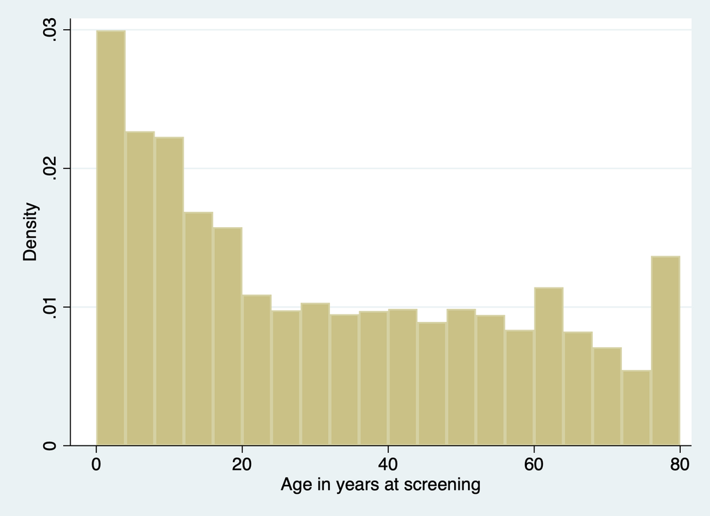

Unweighted Histogram

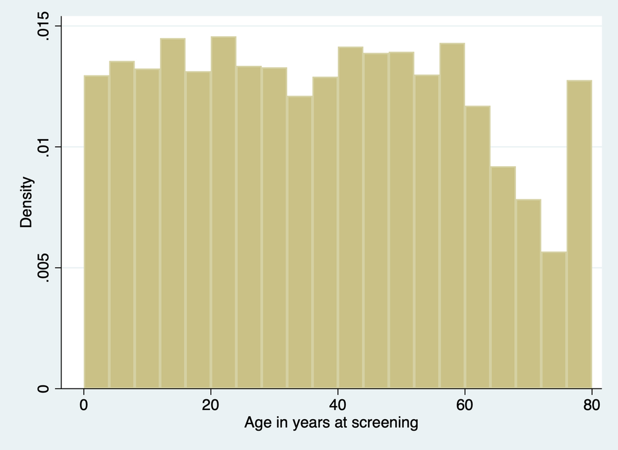

Weighted Histogram

- Distribution of age looks quite different!

## Graphs with Survey Data

- NHANES 2011-2012 – height and weight relationship for 50-year-olds

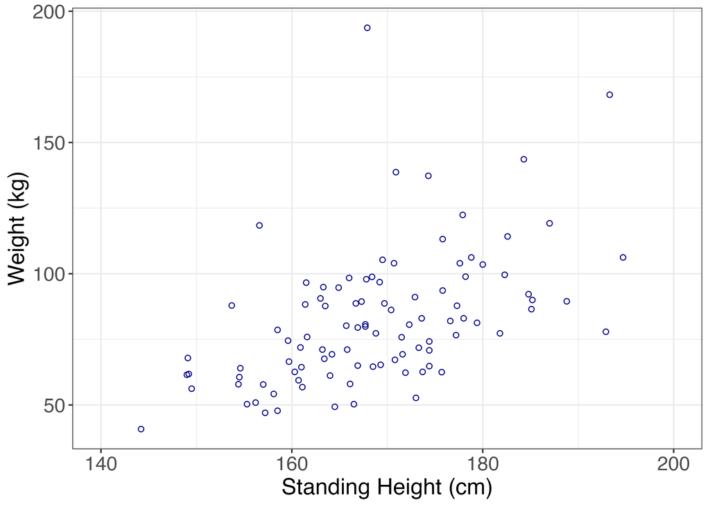

Unweighted Scatterplot

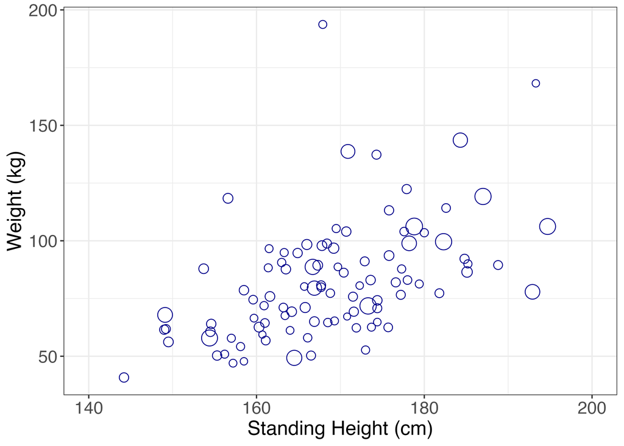

Weighted Scatterplot

- Weighted scatterplot = “Bubble plot”
  - Size of the “bubble” proportional to sample weight

## Graphs with Survey Data

- NHANES 2011-2012 – self-reported health status (age 20+)

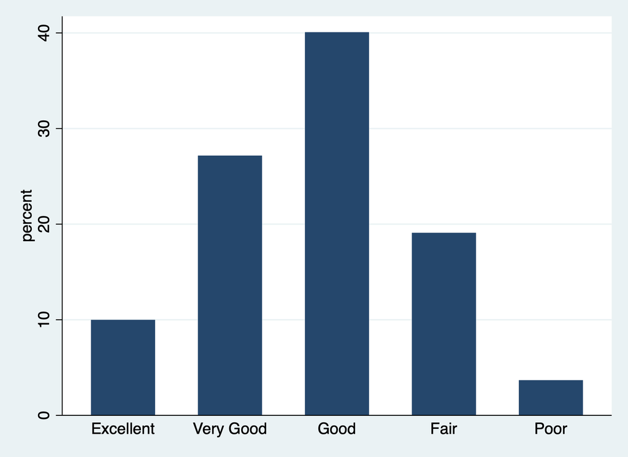

Unweighted Bar Chart

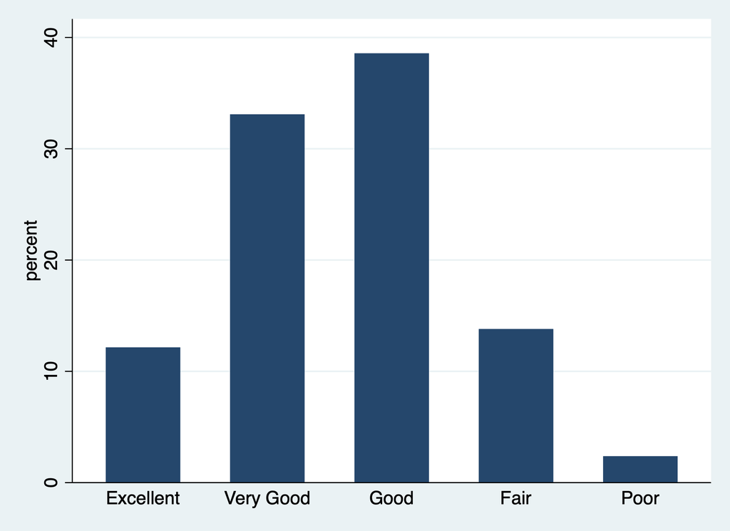

Weighted Bar Chart

- Unweighted distribution overestimates the percentages in the worse health categories (fair, poor)

## Graphs with Survey Data

- NHANES 2011-2012 – # of poor mental health days in past month (age 20+)

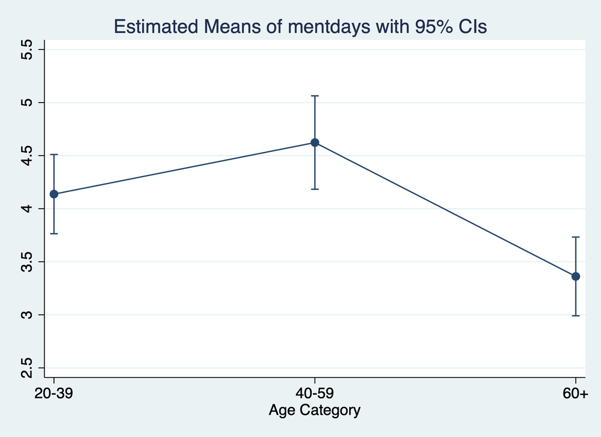

Unweighted Means/CIs

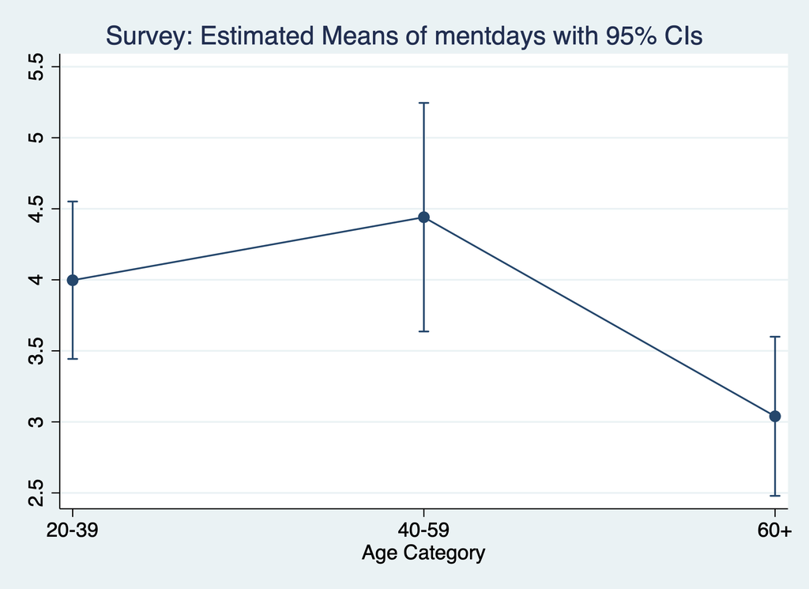

Weighted Means/CIs

## Data Suppression

- Complex probability samples often have large sample sizes
- However, some point estimates may still be quite **variable**
- In addition, estimates based on small numbers of people, or estimates for population groups that are small, might be **dangerous in terms of privacy**
- This leads us to sometimes have to **suppress** survey estimates
  - **Suppression** = Do not release a specific estimate to the public
  - Possible Reason 1: limit risk of **disclosure** – you could figure out who answered the survey
  - Possible Reason 2: estimate is deemed “too variable” or “too unreliable”
- Different statistical agencies use different rules about when to **suppress** results

## Example: Published Analysis Using BRFSS

*Racial and Ethnic Differences in Subjective Cognitive Decline – U.S., 2015–2020.* – [MMWR Morb Mortal Wkly Rep 2023;72:249–255](http://dx.doi.org/10.15585/mmwr.mm7210a1)

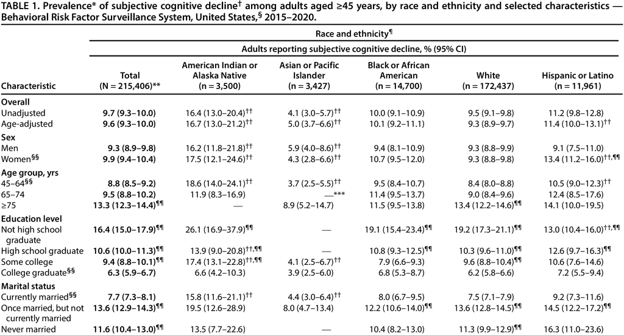

## Some Data Suppression Rules

- **Restrictions on Numerators and/or Denominators of Proportions**
  - Based on the **unweighted** sample sizes, suppress estimates with too few cases in the numerator or denominator of a proportion
    - Example: *Suppress estimates based on proportions with numerator < 10* (National Crime Victimization Survey, NCVS)
    - Example: *Suppress estimates based on proportions with denominator < 30* (National Survey of Family Growth, NSFG)
- **Population Thresholds**
  - Only release estimates for areas/population groups that exceed a certain size
    - Example: *Areas or groups of 65,000 or more are eligible for estimates to be released* (American Community Survey, ACS)

## Some Data Suppression Rules

- **Relative Standard Error (RSE)**

$$RSE = 100 \times \frac{\widehat{SE}(\bar{y})}{|\bar{y}|}$$

- RSE = SE of the estimate divided by (absolute value of) the estimate
- Usually a cutoff is chosen and we suppress estimates with RSE above threshold
- Example: *Suppress estimates with RSE $>$ 30%* (National Health Interview Survey, NHIS)
- Sometimes RSE is modified for proportions: $\frac{\widehat{SE}(\hat{p})/\hat{p}}{-\mathrm{ln}(\hat{p})}>.175$ when $\hat{p} \le$ 0.5